# Jason Hou STA 363 Project 2

Jason Hou

2022-10-25

# Abstract

Renting homes and apartments that belong to local individuals as a place to live has gradually become a new way of finding a place to stay during vacations besides the traditional hotel room, as it provides a cozy, home-like feeling and provides opportunities for people to experience their traveling destinations from a new aspect. Therefore, it is important for platforms like VRBO, which allows individuals to post their homes and apartments for short-term rent, to find methods that help to promote the renting of properties and benefit the platform in long run. The primary goal of this project is to build a model that can be used to predict the price of a rental based on the features of the property, therefore determining the appropriate price property owners should set for their rental properties posted on VRBO to maximize the chance of being rented by travelers. Three regression methods, ridge regression, lasso regression, and elastic net regression were implemented to build this model for predicting the appropriate price of a VRBO rental property. We found the model built through elastic net regression has a better performance in predicting the price of a VRBO rental property, while improvements on the regression methods used can still be performed to further improve the predictive accuracy of the model.

## Part 1: Introduction of Data

We are working on the data set that records 1561 VRBO rental properties. The data set contains information about attributes of the property that might impact the rental price of the properties, including the overall satisfaction score and reviews from customers, the capacity of the properties, location, percentage of rental property nearby, and traffic-related attributes. The goal of our client is to use the data to build a model for predicting the price of a rental, which can be used to help the client to set appropriate prices for new rental properties that make it more likely for them to be rented out.

## Part 2: Data Cleaning

Table 2.1 Number of Missing Values

| x |
| --- |
| 138 |

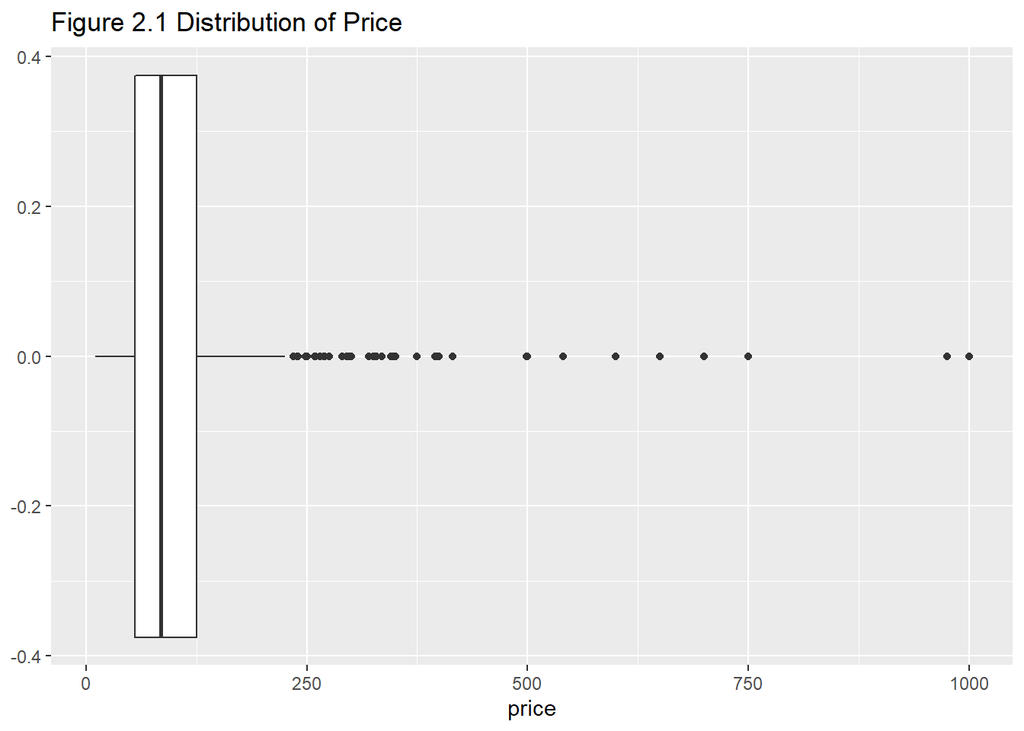

We can see from Table 2.1 that 138 rows with missing values were found in the data set. They are removed from the data set. The 1423 observations were used for the following steps. We can also see that the distribution of the price of VRBO rental properties is rightly skewed.

We identified that the UnitNumber is a feature that should be removed from the data set before building the model, as it has 1423 different levels, and is irrelevant to the price of the VRBO rental properties. A new data set “vrboCleaned” was created for the following sections.

## Part 3: Ridge Regression

We decide to utilize a correlation plot to explore if correlated features exist in the data set. A correlation plot for numeric features in the data set is built to explore if there are potential correlations between features.

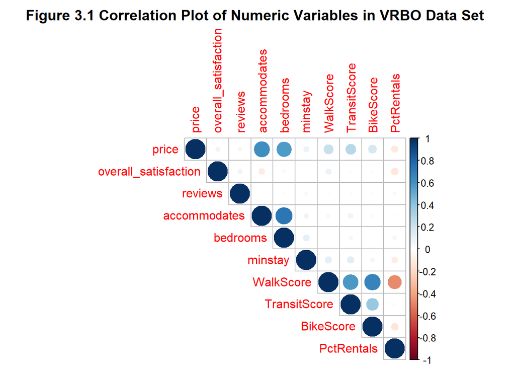

We can see from Figure 3.1 that several significant correlations exist between features. If we use the traditional LSLR to fit the model, unreasonably large coefficients and high variance will occur in the model, which leads to a unusable regression model.Thus, shrinkage and selection techniques are appropriate to be used on building the model to resolve this issue.

Firstly, we use the ridge regression to fit the model, as it provides the effect of shrinkage. That is,shrinking the coefficients of correlated features towards 0, therefore limits the impacts from these features to the model to off set the negative effect induced by multicollinearity(correlated features in data set). For this we need to find the tuning parameter that provides the best shirking effect.

The general form of the model is:
$$\boldsymbol{Y}=\boldsymbol{X_D\beta+\epsilon}$$

The Residual Sum of Squares (RSS) of the model is defined as the standard deviation of observed values in the data set vs predicted values. The equation is :
$$RSS=(\boldsymbol{Y-X_\mathbf{D}\hat{\beta}})^\mathbf{T}(\boldsymbol{Y-X_\mathbf{D}\hat{\beta}})$$

,where XD is our design matrix that consist of all the features in the data set.

For ridge regression ,we use RSS, plus the penalty term $\lambda\boldsymbol{\hat{\beta}^ \mathbf{T}\mathbf{\hat{\beta}}}$, which serves to constraining the regression coefficients under the presence of correlated features.

Our goal is to find the $\boldsymbol{\beta}$ coefficients that minimizes the following:

$$RSS + \lambda
\boldsymbol{\hat{\beta}^\mathbf{T}\mathbf{\hat{\beta}}}=(\boldsymbol{Y-X_\mathbf{D}\hat{\beta}})^T(\boldsymbol{Y-X_\mathbf{D}\hat{\beta}})+\lambda\boldsymbol{\hat{\beta}^\mathbf{T}\mathbf{\hat{\beta}}}$$
To do this, we need to find the value of tuning parameter $\lambda$ that provides the most ideal shrinkage. We fit models with $\lambda$ value from 0 to 50, increment by 0.05 for each time to find the ideal value of $\lambda$. We choose to use the root mean square error(RMSE) to assess the predictive accuracy of each model that uses different values of $\lambda$(tuning parameter). The RMSE is defined as the square root of the mean squared error, which, in other words, the estimated standard deviation of residual of the model.The regression model is said to have less error if the data points are closer to the model, which lead to a smaller RMSE that indicates a better predictive accuracy. The RMSE allows us to assess how well the model fits the observed data points, so that we can determine the predictive accuracy of the model.We use 10 fold Cross Validation to fit the model with to calculate the RMSE and then create a graph of change in RMSE in response of $\lambda$,and select the corresponding $\lambda$ value which provides the ideal extent of shrinkage, as well as balancing bias and variance. The features in the design matrix are standardized when performing 10 fold Cross Validation.

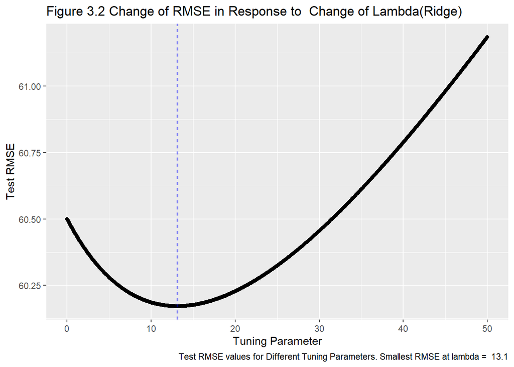

We can see from Figure 3.2 that the smallest RMSE appeared when the model is using $\lambda = 13.1$ as the tuning parameter for the ridge regression. Thus, we chooses this value of $\lambda$ as the $\lambda$ for our final ridge regression model and fit the regression model. The coefficient is shown in the Table 3.2.

Table 3.1 RMSE of Model with Chosen Lambda(Ridge)

|  | Lambda | MSE | RMSE |
| --- | --- | --- | --- |
| 739 | 13.1 | 3620.684 | 60.17212 |

Table 3.2 Coefficients of Model using Ridge Regression

|  | Coefficients |
| --- | --- |
| (Intercept) | -204.4606513 |
| overall_satisfaction | 23.4549403 |
| reviews | -0.0965941 |
| room_typePrivate room | -25.8017054 |
| room_typeShared room | -49.3136829 |
| accommodates | 11.6713342 |
| bedrooms | 28.5518454 |
| minstay | -2.2310041 |
| neighborhoodArcher Heights | -0.2864046 |
| neighborhoodAvondale | -5.9672296 |
| neighborhoodBeverly | 18.1384643 |
| neighborhoodBridgeport | -13.8623440 |
| neighborhoodBrighton Park | -16.1786379 |
| neighborhoodBurnside | -2.4104836 |
| neighborhoodCalumet Heights | 13.3795381 |
| neighborhoodEast Garfield Park | -17.2030932 |
| neighborhoodEdgewater | -7.2232222 |
| neighborhoodEdison Park | 6.9571458 |
| neighborhoodEnglewood | 19.9143447 |
| neighborhoodGage Park | 0.9345814 |
| neighborhoodHegewisch | -2.6627745 |
| neighborhoodHermosa | -16.6406879 |
| neighborhoodHumboldt Park | -8.0579504 |
| neighborhoodHyde Park | -1.5048651 |
| neighborhoodIrving Park | 37.9634866 |
| neighborhoodJefferson Park | -3.1825976 |
| neighborhoodKenwood | 8.9909643 |
| neighborhoodLincoln Park | 29.1683844 |
| neighborhoodLincoln Square | 11.5740617 |
| neighborhoodLogan Square | -7.8696846 |
| neighborhoodMcKinley Park | 0.2970369 |
| neighborhoodMontclare | -21.0368896 |
| neighborhoodMorgan Park | -2.6946591 |
| neighborhoodNear West Side | 22.1976888 |
| neighborhoodNorth Center | 1.9087892 |
| neighborhoodNorth Park | 17.3091888 |
| neighborhoodO’Hare | 30.7994967 |
| neighborhoodPortage Park | -11.3597687 |
| neighborhoodPullman | 25.6733862 |
| neighborhoodRogers Park | -7.1685067 |
| neighborhoodSouth Chicago | -3.8429426 |
| neighborhoodSouth Shore | -5.0672229 |
| neighborhoodThe Loop | 29.7906415 |
| neighborhoodUptown | 2.6967116 |
| neighborhoodWashington Park | 21.9242191 |
| neighborhoodWest Elsdon | 15.4192049 |
| neighborhoodWest Englewood | -74.6598411 |
| neighborhoodWest Lawn | -36.1650269 |
| neighborhoodWest Town | 5.6202352 |
| neighborhoodWoodlawn | -3.9960948 |
| districtFar North | -5.6755428 |
| districtFar Southeast | 5.2195912 |
| districtFar Southwest | 4.3551230 |
| districtNorth | -2.0522277 |
| districtNorthwest | 9.1671145 |
| districtSouth | -4.6327485 |
| districtSouthwest | -4.2667040 |
| districtWest | 0.1523884 |
| WalkScore | 0.5240834 |
| TransitScore | 0.8962553 |
| BikeScore | 0.4273310 |
| PctRentals | -7.5214119 |

Table 3.3 Number of Features in Final Ridge Model

| x |
| --- |
| 61 |

We can see from Table 3.1 and 3.3 that the RMSE of the final ridge regression model has 61 features with an RMSE of 60.17.

## Part 4: Lasso

We then try to use the lasso regression to fit the model for predicting prices of VRBO rental properties since it has the effect of both shrinkage and selection. In other words, lasso regression allows us to remove correlated features from the model to resolve the multicollinearity issue without potentially sacrificing the accuracy of the prediction from the model. Like ridge regression, we need to find the best tuning parameter that controls the selection process and generate the model with the most favorable predictive accuracy.

We use RSS, plus the penalty term $\lambda||\boldsymbol{\hat{\beta}}||_1$ for lasso regression. Our goal is the find the $\boldsymbol{\hat{\beta}}$ that minimize the following:
$$RSS+\lambda||\boldsymbol{\hat{\beta}}||_1 +
=(\boldsymbol{Y-X_\mathbf{D}\hat{\beta}})^T(\boldsymbol{Y-X_\mathbf{D}\hat{\beta}})+\lambda\sum|\hat{\beta_j}|$$
. To do this, we fit models for each $\lambda$ value from 0 to 50, increments by 0.05 for each time, and compare the predictive accuracy of each model to determine the ideal value of $\lambda$.

We choose the RMSE to assess the predictive accuracy of each model with different $\lambda$.We use 10 fold Cross Validation to fit the models and calculate the RMSE and then create a graph of change in RMSE in response of $\lambda$,then select the corresponding $\lambda$ value that provides the shrinkage that balance between variance and bias of the model.The features in the design matrix were standardized when performing 10 fold Cross Validation.

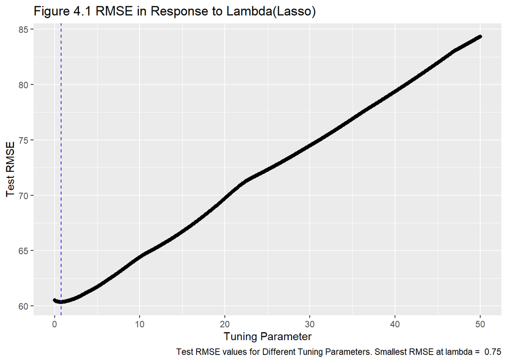

We can see from Figure 4.1 that the lowest RMSE appeared when the model is using $\lambda=0.75$ as the tuning parameter. Thus, we choose $\lambda = 0.75$ as the final model for the prediction of price.The coefficients of the model are listed below in Table 4.2. Features removed during the selection process are marked as “Removed”.

Table 4.1 RMSE with Chosen Lambda(Lasso)

|  | Lambda | MSE | RMSE |
| --- | --- | --- | --- |
| 986 | 0.75 | 3643.552 | 60.36184 |

Table 4.2 Coefficients of Model using Lasso Regression

|  | Coefficients | Selecting.Status |
| --- | --- | --- |
| (Intercept) | -205.3885612 |  |
| overall_satisfaction | 26.0328139 |  |
| reviews | -0.0968850 |  |
| room_typePrivate room | -24.4549695 |  |
| room_typeShared room | -51.5469173 |  |
| accommodates | 13.0249621 |  |
| bedrooms | 29.5220011 |  |
| minstay | -2.0628010 |  |
| neighborhoodArcher Heights | 0.0000000 | Removed |
| neighborhoodAvondale | 0.0000000 | Removed |
| neighborhoodBeverly | 4.7817747 |  |
| neighborhoodBridgeport | -7.9827851 |  |
| neighborhoodBrighton Park | -7.1669134 |  |
| neighborhoodBurnside | 0.0000000 | Removed |
| neighborhoodCalumet Heights | 0.0000000 | Removed |
| neighborhoodEast Garfield Park | -21.1404270 |  |
| neighborhoodEdgewater | -1.1414064 |  |
| neighborhoodEdison Park | 0.0000000 | Removed |
| neighborhoodEnglewood | 0.0000000 | Removed |
| neighborhoodGage Park | 0.0000000 | Removed |
| neighborhoodHegewisch | 0.0000000 | Removed |
| neighborhoodHermosa | 0.0000000 | Removed |
| neighborhoodHumboldt Park | -1.9974979 |  |
| neighborhoodHyde Park | 0.0000000 | Removed |
| neighborhoodIrving Park | 52.4141939 |  |
| neighborhoodJefferson Park | -1.6231343 |  |
| neighborhoodKenwood | 0.0000000 | Removed |
| neighborhoodLincoln Park | 36.7134877 |  |
| neighborhoodLincoln Square | 9.8747942 |  |
| neighborhoodLogan Square | -0.2913011 |  |
| neighborhoodMcKinley Park | 0.0000000 | Removed |
| neighborhoodMontclare | -2.0297808 |  |
| neighborhoodMorgan Park | 0.0000000 | Removed |
| neighborhoodNear West Side | 21.6938427 |  |
| neighborhoodNorth Center | 3.9563540 |  |
| neighborhoodNorth Park | 9.3214800 |  |
| neighborhoodO’Hare | 14.0128581 |  |
| neighborhoodPortage Park | 0.0000000 | Removed |
| neighborhoodPullman | 5.3639424 |  |
| neighborhoodRogers Park | -6.9193310 |  |
| neighborhoodSouth Chicago | 0.0000000 | Removed |
| neighborhoodSouth Shore | -5.8097360 |  |
| neighborhoodThe Loop | 30.6949900 |  |
| neighborhoodUptown | 0.0000000 | Removed |
| neighborhoodWashington Park | 0.0000000 | Removed |
| neighborhoodWest Elsdon | 0.0000000 | Removed |
| neighborhoodWest Englewood | -75.0488728 |  |
| neighborhoodWest Lawn | -28.4718567 |  |
| neighborhoodWest Town | 12.0282047 |  |
| neighborhoodWoodlawn | -12.4164570 |  |
| districtFar North | 0.0000000 | Removed |
| districtFar Southeast | 0.0000000 | Removed |
| districtFar Southwest | 0.0000000 | Removed |
| districtNorth | 0.0000000 | Removed |
| districtNorthwest | 0.0000000 | Removed |
| districtSouth | 0.0000000 | Removed |
| districtSouthwest | 0.0000000 | Removed |
| districtWest | 0.0000000 | Removed |
| WalkScore | 0.0000000 | Removed |
| TransitScore | 1.2786269 |  |
| BikeScore | 0.3346044 |  |
| PctRentals | 0.0000000 | Removed |

Table 4.3 Number of Features in Final Lasso Model

[output not shown]

## Part 5: Elastic Net

Ridge regression is effective in dealing with the situation where we have more features than the number of rows, and constrain the impact of correlated features toward the model, while lasso has the advantage of shrinking and selecting features at the same time. However, ridge regression is unable to select features, and lasso regression is designed to select features instead of shrinking them, which leads to a model with limited features that potentially sacrifices predictive accuracy compared to ridge regression. Therefore, we decide to try to use the elastic net regression, which allows us to use both ridge regression and lasso regression at the same time to balance the shrinkage approach of the ridge regression and the ability of selection from lasso regression, to fit the model for predicting the prices of VRBO rental properties. To build the model with the best predictive accuracy, we need to find the ideal tuning parameters that control the extent of shrinkage and selection when fitting the model.For elastic net, we choose the $\boldsymbol{\hat{\beta}}$ that minimizes
$$RSS + \lambda
\sum((1-\alpha)\hat{\beta_j^2}+\alpha|\hat{\beta_j}|)$$
. We use 10 fold Cross Validation fit models for each value of $\alpha$(from 0 to 1, increment by 0.01 each time) and $\lambda$(from 0 to 25, increment by 0.5 each time), and calculate the RMSE for each model.The features in the design matrix are standardized when performing 10 fold Cross Validation.

Table 5.1 Smallest RMSE with Corresponding Alpha and Lambda

|  | Alpha | Lambda | MSE | RMSE |
| --- | --- | --- | --- | --- |
| 16 | 0.15 | 5 | 3521.362 | 59.34106 |

We can see from Table 5.1 that the lowest RMSE appeared when $\alpha=0.15$ and $\lambda = 5$. Thus we choose $\alpha = 0.15$ and $\lambda = 5$ to be the value of tuning parameters used in the final model. The coefficients of the final model using elastic net regression are list below. Features removed during the selection process are marked with “Removed”.

Table 5.2 Coefficients of Model using Elastic Net

|  | Coefficients | Selecting.Status |
| --- | --- | --- |
| (Intercept) | -200.8993109 |  |
| overall_satisfaction | 24.3692105 |  |
| reviews | -0.0898323 |  |
| room_typePrivate room | -24.7517358 |  |
| room_typeShared room | -49.4513644 |  |
| accommodates | 12.4474265 |  |
| bedrooms | 29.0888356 |  |
| minstay | -1.8168034 |  |
| neighborhoodArcher Heights | 0.0000000 | Removed |
| neighborhoodAvondale | 0.0000000 | Removed |
| neighborhoodBeverly | 5.6518726 |  |
| neighborhoodBridgeport | -8.7753245 |  |
| neighborhoodBrighton Park | -5.0019623 |  |
| neighborhoodBurnside | 0.0000000 | Removed |
| neighborhoodCalumet Heights | 0.0000000 | Removed |
| neighborhoodEast Garfield Park | -17.8336135 |  |
| neighborhoodEdgewater | -1.9732174 |  |
| neighborhoodEdison Park | 0.0000000 | Removed |
| neighborhoodEnglewood | 0.0000000 | Removed |
| neighborhoodGage Park | 0.0000000 | Removed |
| neighborhoodHegewisch | 0.0000000 | Removed |
| neighborhoodHermosa | 0.0000000 | Removed |
| neighborhoodHumboldt Park | -2.2240457 |  |
| neighborhoodHyde Park | 0.0000000 | Removed |
| neighborhoodIrving Park | 49.5352446 |  |
| neighborhoodJefferson Park | -0.0241055 |  |
| neighborhoodKenwood | 0.0000000 | Removed |
| neighborhoodLincoln Park | 34.0477978 |  |
| neighborhoodLincoln Square | 8.1772417 |  |
| neighborhoodLogan Square | -1.6591648 |  |
| neighborhoodMcKinley Park | 0.0000000 | Removed |
| neighborhoodMontclare | -0.3990940 |  |
| neighborhoodMorgan Park | 0.0000000 | Removed |
| neighborhoodNear West Side | 22.6915457 |  |
| neighborhoodNorth Center | 2.1456355 |  |
| neighborhoodNorth Park | 8.4080045 |  |
| neighborhoodO’Hare | 15.2710500 |  |
| neighborhoodPortage Park | 0.0000000 | Removed |
| neighborhoodPullman | 10.7669256 |  |
| neighborhoodRogers Park | -7.0054991 |  |
| neighborhoodSouth Chicago | 0.0000000 | Removed |
| neighborhoodSouth Shore | -4.2545657 |  |
| neighborhoodThe Loop | 31.9318409 |  |
| neighborhoodUptown | 0.0000000 | Removed |
| neighborhoodWashington Park | 0.5523268 |  |
| neighborhoodWest Elsdon | 0.0000000 | Removed |
| neighborhoodWest Englewood | -66.6791921 |  |
| neighborhoodWest Lawn | -26.6078022 |  |
| neighborhoodWest Town | 11.0491058 |  |
| neighborhoodWoodlawn | -8.1195580 |  |
| districtFar North | 0.0000000 | Removed |
| districtFar Southeast | 0.0000000 | Removed |
| districtFar Southwest | 0.0000000 | Removed |
| districtNorth | 0.0000000 | Removed |
| districtNorthwest | 0.0000000 | Removed |
| districtSouth | 0.0000000 | Removed |
| districtSouthwest | 0.0000000 | Removed |
| districtWest | 0.0000000 | Removed |
| WalkScore | 0.2161760 |  |
| TransitScore | 1.1068642 |  |
| BikeScore | 0.3297103 |  |
| PctRentals | -0.6639934 |  |

Table 5.3 Number of Features in Final Elastic Net Model

| x |
| --- |
| 36 |

We can see from Table 5.1 and 5.3 that the final elastic net model has 36 features with an RMSE of 59.34.

## Part 6: Comparison and Conclusion

We listed out the coefficient table of three regression method we used, and compare tuning parameter and predictive accuracy of the three models.

Table 6.1 Coefficients of Ridge, Lasso and Elastic Net Regression

| Ridge | Lasso | Elastic.Net |
| --- | --- | --- |
| -204.4606513 | -205.3885612 | -200.8993109 |
| 23.4549403 | 26.0328139 | 24.3692105 |
| -0.0965941 | -0.0968850 | -0.0898323 |
| -25.8017054 | -24.4549695 | -24.7517358 |
| -49.3136829 | -51.5469173 | -49.4513644 |
| 11.6713342 | 13.0249621 | 12.4474265 |
| 28.5518454 | 29.5220011 | 29.0888356 |
| -2.2310041 | -2.0628010 | -1.8168034 |
| -0.2864046 | 0.0000000 | 0.0000000 |
| -5.9672296 | 0.0000000 | 0.0000000 |
| 18.1384643 | 4.7817747 | 5.6518726 |
| -13.8623440 | -7.9827851 | -8.7753245 |
| -16.1786379 | -7.1669134 | -5.0019623 |
| -2.4104836 | 0.0000000 | 0.0000000 |
| 13.3795381 | 0.0000000 | 0.0000000 |
| -17.2030932 | -21.1404270 | -17.8336135 |
| -7.2232222 | -1.1414064 | -1.9732174 |
| 6.9571458 | 0.0000000 | 0.0000000 |
| 19.9143447 | 0.0000000 | 0.0000000 |
| 0.9345814 | 0.0000000 | 0.0000000 |
| -2.6627745 | 0.0000000 | 0.0000000 |
| -16.6406879 | 0.0000000 | 0.0000000 |
| -8.0579504 | -1.9974979 | -2.2240457 |
| -1.5048651 | 0.0000000 | 0.0000000 |
| 37.9634866 | 52.4141939 | 49.5352446 |
| -3.1825976 | -1.6231343 | -0.0241055 |
| 8.9909643 | 0.0000000 | 0.0000000 |
| 29.1683844 | 36.7134877 | 34.0477978 |
| 11.5740617 | 9.8747942 | 8.1772417 |
| -7.8696846 | -0.2913011 | -1.6591648 |
| 0.2970369 | 0.0000000 | 0.0000000 |
| -21.0368896 | -2.0297808 | -0.3990940 |
| -2.6946591 | 0.0000000 | 0.0000000 |
| 22.1976888 | 21.6938427 | 22.6915457 |
| 1.9087892 | 3.9563540 | 2.1456355 |
| 17.3091888 | 9.3214800 | 8.4080045 |
| 30.7994967 | 14.0128581 | 15.2710500 |
| -11.3597687 | 0.0000000 | 0.0000000 |
| 25.6733862 | 5.3639424 | 10.7669256 |
| -7.1685067 | -6.9193310 | -7.0054991 |
| -3.8429426 | 0.0000000 | 0.0000000 |
| -5.0672229 | -5.8097360 | -4.2545657 |
| 29.7906415 | 30.6949900 | 31.9318409 |
| 2.6967116 | 0.0000000 | 0.0000000 |
| 21.9242191 | 0.0000000 | 0.5523268 |
| 15.4192049 | 0.0000000 | 0.0000000 |
| -74.6598411 | -75.0488728 | -66.6791921 |
| -36.1650269 | -28.4718567 | -26.6078022 |
| 5.6202352 | 12.0282047 | 11.0491058 |
| -3.9960948 | -12.4164570 | -8.1195580 |
| -5.6755428 | 0.0000000 | 0.0000000 |
| 5.2195912 | 0.0000000 | 0.0000000 |
| 4.3551230 | 0.0000000 | 0.0000000 |
| -2.0522277 | 0.0000000 | 0.0000000 |
| 9.1671145 | 0.0000000 | 0.0000000 |
| -4.6327485 | 0.0000000 | 0.0000000 |
| -4.2667040 | 0.0000000 | 0.0000000 |
| 0.1523884 | 0.0000000 | 0.0000000 |
| 0.5240834 | 0.0000000 | 0.2161760 |
| 0.8962553 | 1.2786269 | 1.1068642 |
| 0.4273310 | 0.3346044 | 0.3297103 |
| -7.5214119 | 0.0000000 | -0.6639934 |

Table 6.2 Comparison Across Ridge Regression, Lasso Regression and Elastic Net Regression on Tuning Parameter, Predictive Accuracy Metrics, and Features(intercept removed)

[output not shown]

We can see from Table 6.2 that the RMSE of model built through ridge regression, lasso regression and elastic net regression, which indicates the estimated standard deviation of residuals of the model, are 60.17, 60.36 and 59.34, respectively. The RMSE of final ridge regression model is 60.17, which is about 0.3% lower than the RMSE of model built with lasso regression.The RMSE of model built through elastic net is 1.7% lower than the model built with lasso, and 1.4% lower than the model built with ridge. We can see that the elastic net model performs better at prediction than the other two models. The model fitted with elastic net has the lowest RMSE of 59.34 (with $\alpha = 0.15$ and $\lambda = 5$) among the three models fitted model, consider the range the price varies in the data set(from 0 to 1000), this RMSE of 59.34 indicates a relatively better fit of the model to the data points, which lead to a better predictive accuracy of the model and simultaneously balances bias and variance.

While ridge regression allows us to keep all the features provided in the model, including all the features in the model could increase model’s complexity, making it hard to interpret when compared with lasso and elastic net. Lasso regression allows us to completely remove correlated features instead of shrinking them, but it also imposes limitation on the number of features selected, which lead to a lower predictive accuracy compared to ridge regression and lasso regression as it shown in Table 6.2, where we can see that the elastic net regression model performs better at prediction than the other two models.

Based on the information we have obtained, we conclude that the model built with elastic net regression offers the best prediction to the price of VRBO rental properties, and we recommend the client to choose it as the model for predicting the price of a VRBO rental property. The limitation that the model has in real-world setting is that it can be computationally expensive, since the process of finding the best tuning parameters can be lengthy when the model is applied to a large data set. We also suggest that a mixed effect model could also be introduced to fit regression model, as it has the ability of addressing the random effects(variance due to difference between neighborhood blocks and districts, and variances due to the difference among each individual rental property within the block/district.